# Modeling Workforce Retention in R

Author

Gordon Goodwin

This guide illustrates how **survival analysis** techniques can be used to analyze & predict **employee attrition & retention** using `R`.

# Case Study

For this guide, we’ll use an illustrative case study based on real scenarios from my professional experience.

**The data used here can be found on my [Github page](https://github.com/gordon-goodwin/gordon-goodwin.github.io/tree/main/R_projects/data) and was simulated to protect confidentiality, but still reflects real patterns and insights. Please reach out with Q’s!**

## Context

GMG Automotives is a regional automotive manufacturer with 3 production facilities in `Denver CO`, `Tampa FL`, and `Charlotte NC`.

- All 3 facilities have been open ~1 year (opened June 2023).
- All 3 facilities have a “cohort-style” hiring strategy, with 2 main hire classes that started in June 2023 and Jan 2024 respectively.
- Plant Mgmt had hoped that the Jan 2024 hire class would be sufficient to maintain sufficient staffing levels for at least 6 months (June 2024).

## Problem

Over last few months, the Chief HR Officer (CHRO) has received anecdotal reports from plant management that employee turnover is alarmingly high and trending upwards

- The Talent Aquisition (TA) team is having difficulty drafting a hiring strategy that will support a stable average headcount of 200 employees at each facility

## Objective

Model **employee attrition**, identify **risk factors**, and **predict retention probabilities** over time.

### Business Questions

- *What % of employees can be expected to retain past the training (30d) and probationary (90d) periods?*
- *Are there any risk factors that may impact the probability an employee retains?*
  - Facility (`Denver`, `Tampa`, `Charlotte`)
  - Hire Cohort (`June 2023`, `Jan 2024`)
- *How can we leverage this information to inform workforce planning strategy?*
  - Goal = stable headcount of 200 employees at each facility

## Data

We have obtained basic HR data that reflects the most recent employee information, `employment status`, and `seniority time` available for each employee.

```r
# No Scientific Notation
options(scipen = 999)

# Source Functions
library(tidyverse)
library(tidymodels)
library(censored)
library(janitor)
library(ggfun)
library(survminer)
library(ggsurvfit)
library(patchwork)
library(gt)

# Read Data
read_csv("Survival Analysis PA Tutorial.csv") |> clean_names() -> dat1

# Format
dat1 |>
  mutate(hire_date = mdy(hire_date),
         max_date_recorded = mdy(max_date_recorded),
         hire_date = factor(hire_date),
         facility = factor(facility),
         transfer = factor(transfer),
         manager = factor(manager),
         termination_status = factor(termination,
                                     labels = c("Active","Termed"))) -> dat1


# Preview
dat1 |>
  select(emp_id, facility, manager, hire_date,
         seniority_recorded, termination_status) |>
  gt::gt_preview()
```

|  | emp_id | facility | manager | hire_date | seniority_recorded | termination_status |
| --- | --- | --- | --- | --- | --- | --- |
| 1 | x95 | A: Denver | Jacob | 2023-06-01 | 365 | Active |
| 2 | x90 | A: Denver | Susan | 2023-06-01 | 365 | Active |
| 3 | x89 | A: Denver | Jacob | 2023-06-01 | 365 | Active |
| 4 | x84 | A: Denver | Susan | 2023-06-01 | 365 | Active |
| 5 | x97 | A: Denver | Jacob | 2023-06-01 | 350 | Termed |
| 6..149 |  |  |  |  |  |  |
| 150 | x25 | C: Charlotte | Jacob | 2024-01-01 | 120 | Active |

This data format is known as **time-to-event** data, as it allows us to answer questions about how long an object or subject can be expected to “survive” before some event of interest occurs.

In employee attrition contexts, the “subjects” are employees, the “event” is termination, and our objective is to **model how long employees can be expected to retain before terminating**.

# Results

Our results are organized into 3 main sections:

1. **Headcount Trends**
2. **Baseline Retention**
3. **Group Differences**

## Headcount

*Have staffing thresholds consistently been met in 2024 across all 3 facilities?*

Visualizing our headcount trends across facilities reveals **2 main problems**:

- Both the **`Tampa FL`** and **`Charlotte NC`** facilities currently have staffing levels **below** the 200-employee threshold needed to sustain operations
- While all 3 facilities have followed the same hiring strategy, differences in attrition have led to headcount discrepancies that **get wider over time**

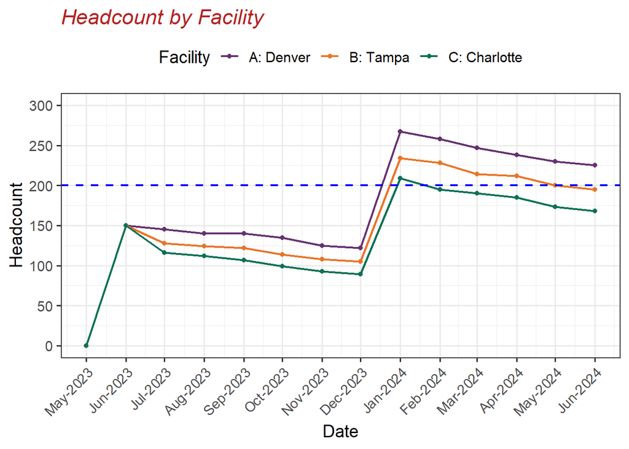

```r
# Read Data
read_csv("Headcount Trend PA Tutorial.csv") |> clean_names() -> dat2

# Format
dat2 |>
  mutate(date = mdy(date),
         facility = factor(facility)) -> dat2

# Plot
dat2 |>
  ggplot(aes(x = date,
             y = headcount,
             color = facility,
             group = facility)) +
  geom_point() +
  geom_line(linewidth = 0.75) +
  scale_x_date(date_breaks = "1 month",
               date_labels = "%b-%Y") +
  scale_y_continuous(breaks = seq(0, 300, 50),
                     limits = c(0, 300)) +
  scale_color_manual(values = c("#663171", "#ea7428","#0c7156")) +
  geom_hline(yintercept = 200, lty = 2, linewidth = 0.75, color = "blue") +
  theme_bw(base_size = 14) +
  theme(legend.position = "top",
        plot.title = element_text(face = "italic",color = "firebrick"),
        axis.text.x = element_text(angle = 45, vjust =1, hjust=1)) +
  labs(x = "Date", y = "Headcount", color = "Facility",
       title = "Headcount by Facility")
```

## Baseline Retention

*How long can the typical GMG Auto employee be expected to retain after hire?*

Below, our **baseline retention curve** displays the probability of an employee retaining past a given seniority point:

- *Roughly **~80%** of employees can be expected to **retain past training (30d)***
- *Around **~60%** of employees can be expected to **retain past probation (90d)***
- *A little over **40%** of employees can be expected to **retain past 6m***
- *Less than **20%** of employees can be expected to **retain past 12m***

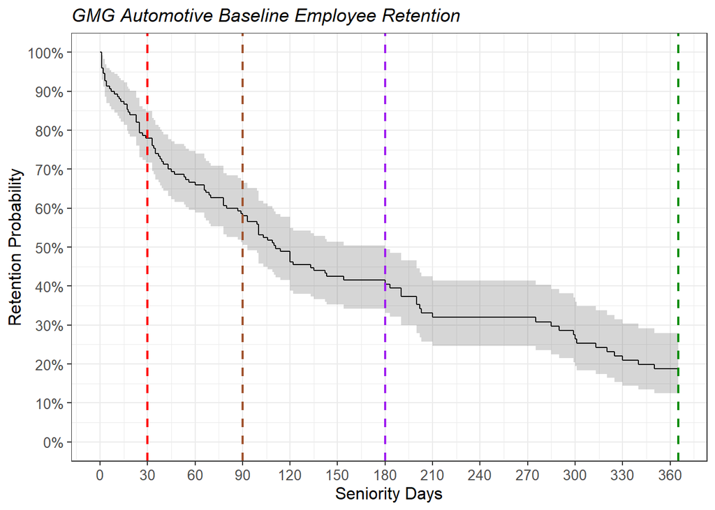

```r
# Plot Survival Curve using prebuilt fns
survfit2(Surv(seniority_recorded, termination) ~ 1, data = dat1) |>
  ggsurvfit() +
  labs(
    x = "Seniority Days",
    y = "Retention Probability",
    title = "GMG Automotive Baseline Employee Retention"
  ) +
  add_confidence_interval() +
  # add_censor_mark() +
  # add_risktable(risktable_stats = c("n.risk",
  #                                  "n.event")) +
  scale_y_continuous(labels = scales::label_percent(),
                     breaks = seq(0, 1, .1),
                     limits = c(0, 1)) +
  scale_x_continuous(breaks = seq(0, 365, 30),
                     limits = c(0, 365)) +
  geom_vline(xintercept = 30, color = "red", linewidth = .8, lty = 2) +
  geom_vline(xintercept = 90, color = "sienna", linewidth = .8, lty = 2) +
      geom_vline(xintercept = 180, color = "purple", linewidth = .8, lty = 2) +
    geom_vline(xintercept = 365, color = "green4", linewidth = .8, lty = 2) +
  theme(plot.title = element_text(face = "italic"))
```

We can also format this retention curve as a **survival table**:

```r
## Fit Kaplan Maier Survival Model
survfit(Surv(time = seniority_recorded,
             event = termination) ~ 1,
        data = dat1) -> survmod_overall

# Table of summary results
data.frame(time = survmod_overall$time,
           n_risk = survmod_overall$n.risk,
           n_event = survmod_overall$n.event,
           n_censored = survmod_overall$n.censor,
           survival = survmod_overall$surv,
           std_error = survmod_overall$std.err,
           ci_95_lower = survmod_overall$lower,
           ci_95_upper = survmod_overall$upper) |>
  mutate(across(where(is.numeric),
                ~round(.x, 2)))-> survtab_overall

survtab_overall |>
  filter(time %in% c(90, 180, 365)) |>
  select(`Seniority Days` = time,
         `Retention Rate` = survival,
         `Conf Int Lower` = ci_95_lower,
         `Conf Int Upper` = ci_95_upper) |>
  gt() |>
    tab_header(title = "Retention at 3m, 6m, & 12m Seniority",
               subtitle = "GMG Automotive Employees") |>
  fmt_percent(columns = c(`Retention Rate`), decimals = 0)
```

Retention at 3m, 6m, & 12m Seniority

GMG Automotive Employees

| Seniority Days | Retention Rate | Conf Int Lower | Conf Int Upper |
| --- | --- | --- | --- |
| 90 | 58% | 0.51 | 0.66 |
| 180 | 41% | 0.33 | 0.49 |
| 365 | 18% | 0.12 | 0.27 |

## Group Differences

In order to probe for **group differences** and **risk factors** in attrition and retention rates, we’ve now calculated **group-level** retention curves and tables**.**

### Facilities

*Do retention rates vary by facility? Can an employee’s facility predict their odds of terminating?*

The **retention curve** below supports the following insights:

- *Retention rates **do** vary significantly by facility*
  - Employees at the **`Denver, CO`** facility have the **greatest chance of retaining** over time.
  - Employees at the **`Charlotte NC`** facility have the **lowest chance of retaining** over time.
  - **`Tampa FL`** falls somewhere in the middle

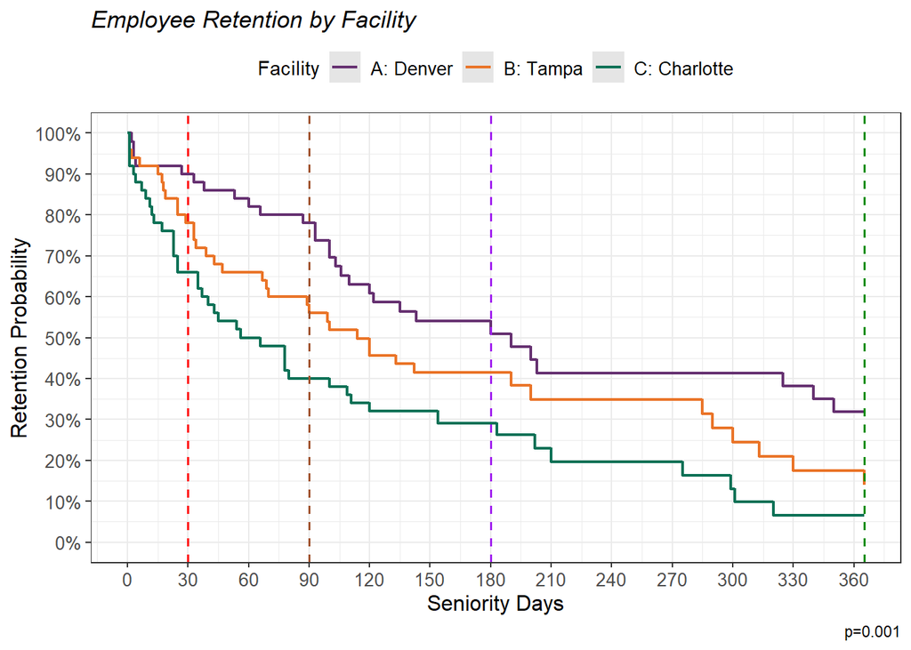

```r
# Plot Curve - ggsurvfit
survfit2(Surv(time = seniority_recorded,
              event = termination) ~ facility,
         data = dat1) |>
  ggsurvfit(linewidth = 0.8) +
  # add_confidence_interval() +
  add_pvalue() +
  scale_y_continuous(labels = scales::label_percent(),
                     breaks = seq(0, 1, .1),
                     limits = c(0, 1)) +
  scale_x_continuous(breaks = seq(0, 365, 30),
                     limits = c(0, 365)) +
  geom_vline(xintercept = 30, color = "red", linewidth = .65, lty = 2) +
  geom_vline(xintercept = 90, color = "sienna", linewidth = .65, lty = 2) +
      geom_vline(xintercept = 180, color = "purple", linewidth = .65, lty = 2) +
    geom_vline(xintercept = 365, color = "green4", linewidth = .65, lty = 2) +
  scale_color_manual(values = c("#663171", "#ea7428","#0c7156")) +
  scale_fill_manual(values = c("#663171", "#ea7428","#0c7156")) +
  labs(x = "Seniority Days",y = "Retention Probability",
       color = "Facility",fill = "Facility",
       title = "Employee Retention by Facility") +
  theme(legend.position = "top",
        plot.title = element_text(face = "italic"),
        legend.key = element_rect(fill = "grey90"))
```

As seen below, we can also use a **hazard model** to quantify the impact that an employee’s facility assignment has upon their **odds of terminating**.

Using `Denver CO` as the reference group, we can see that:

- *Employees at the* **`Tampa FL`** *facility are **~1.6x more likely to terminate** over time than their* **`Denver CO`** *peers.*
- *Employees at the* **`Charlotte NC`** *facility are **~2.4x more likely to terminate** over time than their peers at the* **`Denver CO`** facility.

```r
# Facility as a covariate for the hazard of termination
coxmod_facility <- coxph(Surv(time = seniority_recorded,
                               event = termination) ~ facility,
                          data = dat1)

# Output
coxmod_facility |> gtsummary::tbl_regression(exp = T)
```

| **Characteristic** | **HR**<sup>1</sup> | **95% CI**<sup>1</sup> | **p-value** |
| --- | --- | --- | --- |
| facility |  |  |  |
| A: Denver | — | — |  |
| B: Tampa | 1.62 | 0.99, 2.63 | 0.054 |
| C: Charlotte | 2.38 | 1.47, 3.84 | <0.001 |

<sup>1</sup> HR = Hazard Ratio, CI = Confidence Interval

### Hire Cohorts

*Is employee retention getting worse? Are the Jan 2024 hires more likely to terminate?*

The **retention curve** below supports the following insights:

- *Employees hired in the* **`Jan 2024`** *cohort **retain worse** than those in the* **`June 2023`** *cohort*
- *The gap in retention probabilities appears to get **wider over time***
  - At the **30d** mark, the retention rate for the `June 2023` is **only 7pp greater** than that of the `Jan 2024` cohort (82% vs 75%)
  - At the **90d** mark, the `June 2023` cohort has a retention rate that is **over 20pp greater** than the `Jan 2024` cohort (70% vs 50%)

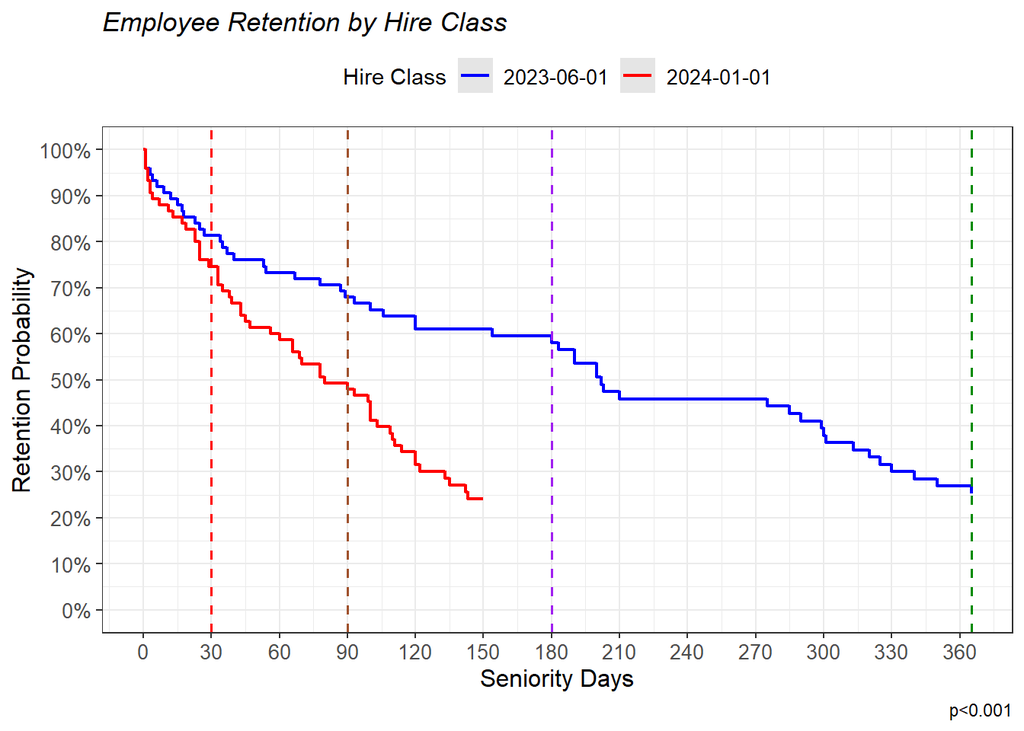

```r
# Plot Curve - ggsurvfit
survfit2(Surv(time = seniority_recorded,
              event = termination) ~ hire_date,
         data = dat1) |>
  ggsurvfit(linewidth = 0.8) +
  # add_confidence_interval() +
  add_pvalue() +
  scale_y_continuous(labels = scales::label_percent(),
                     breaks = seq(0, 1, .1),
                     limits = c(0, 1)) +
  scale_x_continuous(breaks = seq(0, 365, 30),
                     limits = c(0, 365)) +
  geom_vline(xintercept = 30, color = "red", linewidth = .65, lty = 2) +
  geom_vline(xintercept = 90, color = "sienna", linewidth = .65, lty = 2) +
      geom_vline(xintercept = 180, color = "purple", linewidth = .65, lty = 2) +
    geom_vline(xintercept = 365, color = "green4", linewidth = .65, lty = 2) +
  scale_color_manual(values = c("blue", "red","#0c7156")) +
  scale_fill_manual(values = c("blue", "red","#0c7156")) +
  labs(x = "Seniority Days",y = "Retention Probability",
       color = "Hire Class",fill = "Hire Class",
       title = "Employee Retention by Hire Class") +
  theme(legend.position = "top",
        plot.title = element_text(face = "italic"),
        legend.key = element_rect(fill = "grey90"))
```

Similarly, as shown below, a **hazard model** shows that:

- *Employees from the* `Jan 2024` hire class *are **over 2.4x more likely to terminate** over time than employees hired in the* **`June 2023`** cohort.

```r
# Hire Cohort as a covariate for the hazard of termination
coxmod_hiredate <- coxph(Surv(time = seniority_recorded,
                               event = termination) ~ hire_date,
                          data = dat1)

# Output
coxmod_hiredate |> gtsummary::tbl_regression(exp = T)
```

| **Characteristic** | **HR**<sup>1</sup> | **95% CI**<sup>1</sup> | **p-value** |
| --- | --- | --- | --- |
| hire_date |  |  |  |
| 2023-06-01 | — | — |  |
| 2024-01-01 | 2.44 | 1.55, 3.83 | <0.001 |

<sup>1</sup> HR = Hazard Ratio, CI = Confidence Interval

# Conclusions

Our analysis supports 3 primary conclusions & recommendations:

1. **Attrition & retention rates vary significantly between facilities**, which in turn leads to inconsistent headcount fluctuations.
   1. *We should consider interviewing both staff and management at the `Denver CO` facility to understand why their employees retain so much better.*
   2. *We should similarly interview the `Charlotte NC` facility to understand why their employees retain so poorly*
2. **A uniform hiring strategy for all 3 locations will not be sufficient** to maintain a 200-employee threshold at each facility until attrition rates are consistent.
   1. *We should consider a 3-tiered approach to hire targets that prioritizes allocation in order of* `Charlotte NC`*,* `Tampa FL`, and then `Denver CO`.
3. **Underlying attrition rates seem to be getting worse**, as the `Jan 2024` cohort is retaining at a significantly lower rate than the `June 2023` class.
   1. *We should consult plant management to see if there has been any external change or seasonal variations in workload that might explain the recent decline*
   2. *We should consider increasing the next hire class size above for all 3 facilities to be safe*